# Take Home Exercise 03

A Study on the Financial health of the residents og Engagement, Ohio, USA.

Rakendu Ramesh https://www.linkedin.com/in/rakendu-ramesh/ (Singapore Management University)https://www.linkedin.com/showcase/smumitb/  
2022-05-15

# Overview

In this Take Home exercise, we strive to answer the following questions about the financial health of the residents of Engagement, Ohio, USA.

- How does the financial health of the residents change over the period covered by the dataset?
- How do wages compare to the overall cost of living in Engagement?
- Are there groups that appear to exhibit similar patterns?

## Dataset

The dataset used is available for download [*here*](https://vast-challenge.github.io/2022/). Out of the data available, we will be using the Financial Journal to understand the income and expense of the participants over a period of time.

## Getting Started

We will first load the required packages using the below code chunk

```r
packages = c('tidyverse','ggdist','gghalves','ggthemes','hrbrthemes','ggridges','patchwork','zoo', 'ggrepel','ggiraph','lubridate')
for(p in packages){
  if(!require(p, character.only = T)){
    install.packages(p)
  }
  library(p, character.only = T)
}
```

## Importing Data

The code chunk below imports *FinancialJournal.csv* and *Participants.csv* from the data folder by using [`read_csv()`](https://readr.tidyverse.org/reference/read_delim.html) function of [**readr**](https://readr.tidyverse.org/index.html) package into R and save it as a tibble dataframe called *financial_data*.

```r
financial_data <- read_csv("data/FinancialJournal.csv")
participants_data <- read_csv("data/Participants.csv")
```

## Data Wrangling

In the below code chunk, financial data of participants are grouped by Month and Aggregated to find their monthly Income and Expenses. The data is then joined with Participants data so that we have information about participants education level and other details.

```r
level_order <- c('Graduate','Bachelors','HighSchoolOrCollege','Low')

participant_fin <- financial_data %>%
  mutate(date = as.yearmon(timestamp)) %>%
  group_by(participantId, date) %>%
  summarise(income = sum(ifelse(amount > 0,amount,0)), expense = sum(ifelse(amount <= 0,amount,0))) %>%
  inner_join(participants_data, by =c('participantId'))%>%
  mutate(educationLevel = factor(educationLevel, levels = level_order))
```

We will further wrangle the data to find the average income of participants with different Education Levels.

```r
Education_fin <- participant_fin %>%
  group_by(educationLevel,date) %>%
  summarise(income = mean(income), expense= mean(expense))
```

## Visualising the Income of Participants to understand if the Education Level has any impact

From the below plot, we can see that the participants with Low education have lower Income where as participants with Graduate and Bachelor level education has higher Income. It is observed that there is a major dip in Income in April, 2022 and Feb, 2023 where as the income is high in March,2022, Aug,2022 and March 2023.

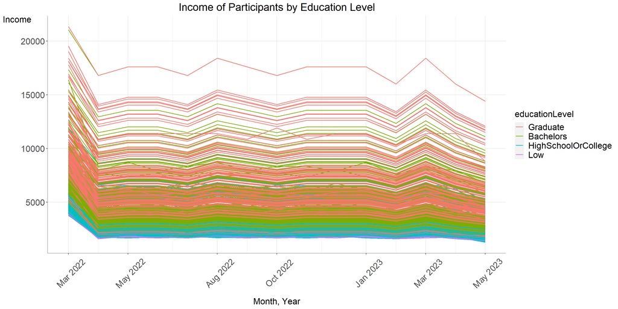

```r
participant_fin %>%
  ggplot(aes(x=date, y = income, group =participantId, color =educationLevel))+
  geom_line_interactive(size = 0.6)+
  ylab("Income")+
  xlab("Month, Year")+
  theme(axis.title.y=element_text(angle =0, margin = margin(t=-50,r=-20)),
        axis.title.x=element_text(margin = margin(t=-10)),
        panel.grid.minor.y = element_blank(),
        panel.grid.minor.x = element_line(colour = "grey90"),
        panel.grid.major.x = element_line(colour = "grey90"),
        panel.grid.major.y = element_line(colour = "grey90"),
        panel.background = element_rect(fill = "white"),
        axis.text.x = element_text(size =16, angle = 45, margin = margin(t = 30)),
        axis.text.y = element_text(size =16),
        axis.line = element_line(color="grey25", size = 0.02),
        axis.title = element_text(size=16),
        legend.title = element_text(size =16),
        legend.text = element_text(size = 16),
        plot.title = element_text(size =20,hjust = 0.5))+
  ggtitle("Income of Participants by Education Level")
```

Since there are too many lines, let us add a tooltip to display the income and education level on hover

```r
participant_fin$tooltip <- c(paste0(
  "Id = ", participant_fin$participantId,
  "\n Income = $", round(participant_fin$income,digits = 0),
  "\n Education :",participant_fin$educationLevel))

p1 <- participant_fin %>%
  ggplot(aes(x=date, y = income, group =participantId, color =educationLevel))+
  geom_line_interactive(aes(tooltip = tooltip),size =0.3)+
  ylab("Income")+
  xlab("Month, Year")+
  theme(panel.grid.minor.y = element_blank(),
        panel.grid.minor.x = element_line(colour = "grey90"),
        panel.grid.major.x = element_line(colour = "grey90"),
        panel.grid.major.y = element_line(colour = "grey90"),
        panel.background = element_rect(fill = "white"),
        axis.text.x = element_text( angle = 45, margin = margin(t = 30)),
                axis.line = element_line(color="grey25", size = 0.02))+
  ggtitle("Income of Participants by Education Level")

girafe(
  ggobj = p1,
  width_svg = 6,
  height_svg = 6*0.618
)
```

[interactive chart not shown]

Let us clean up this graph to see the average Income by Education Level

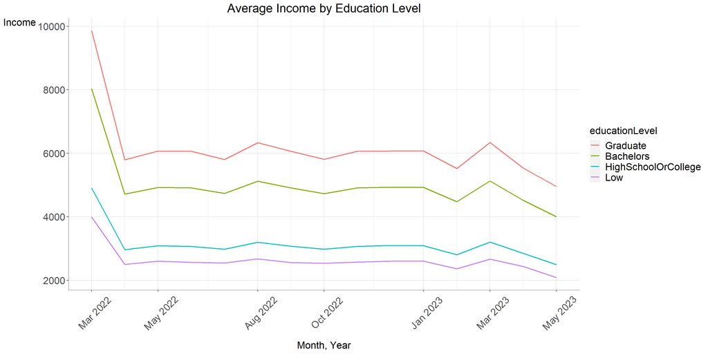

```r
Education_fin %>%
  ggplot(aes(x=date, y = income,col =educationLevel))+
  geom_line(size = 0.75)+
  ylab("Income")+
  xlab("Month, Year")+
  theme(axis.title.y=element_text(angle =0),
        axis.title.x=element_text(margin = margin(t=-10)),
        panel.grid.minor.y = element_blank(),
        panel.grid.minor.x = element_line(colour = "grey90"),
        panel.grid.major.x = element_line(colour = "grey90"),
        panel.grid.major.y = element_line(colour = "grey90"),
        panel.background = element_rect(fill = "white"),
        axis.text.x = element_text(size =16, angle = 45, margin = margin(t = 30)),
        axis.text.y = element_text(size =16),
        axis.line = element_line(color="grey25", size = 0.02),
        axis.title = element_text(size=16),
        legend.title = element_text(size =16),
        legend.text = element_text(size = 16),
        plot.title = element_text(size =20,hjust = 0.5))+
  ggtitle("Average Income by Education Level")
```

Let us now try to visualize both income and expense of different Education Levels on the same graph

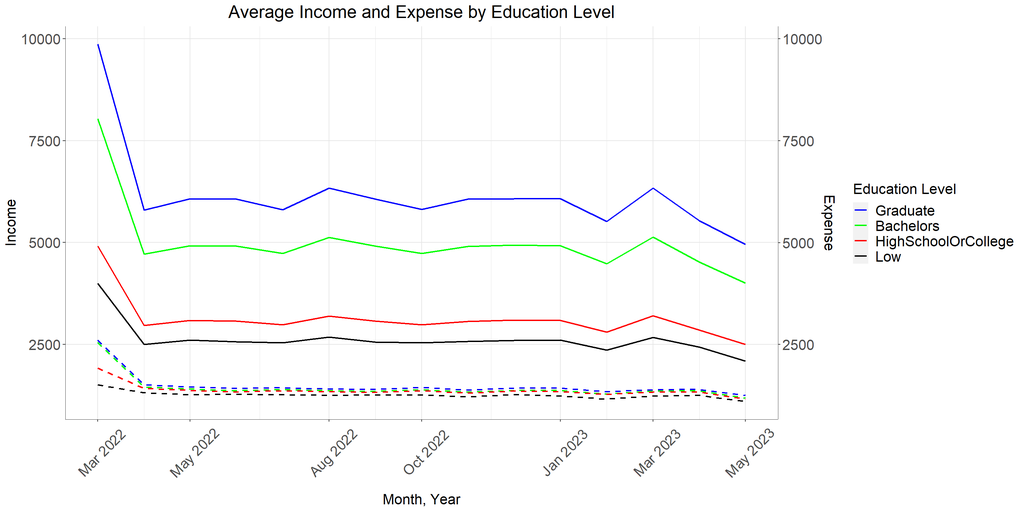

```r
Education_fin %>%
  ggplot(aes(x=date))+
  geom_line(aes(y= income,col =educationLevel),size = 0.75)+
  geom_line(aes(y = abs(expense), col =educationLevel ),size = 0.75,linetype = 2)+
  scale_color_manual('Education Level', values = c('blue','green','red','black'))+
  scale_linetype_manual(name='Income/Expense',values = c(1,2), labels = c('income','expense'))+
  scale_y_continuous(name = "Income",
                     sec.axis = sec_axis(trans = ~.,name="Expense"))+
  xlab("Month, Year")+
    theme(
        axis.title.x=element_text(margin = margin(t=-10)),
        panel.grid.minor.y = element_blank(),
        panel.grid.minor.x = element_line(colour = "grey90"),
        panel.grid.major.x = element_line(colour = "grey90"),
        panel.grid.major.y = element_line(colour = "grey90"),
        panel.background = element_rect(fill = "white"),
        axis.text.x = element_text(size =16, angle = 45, margin = margin(t = 30)),
        axis.text.y = element_text(size =16),
        axis.line = element_line(color="grey25", size = 0.02),
        axis.title = element_text(size=16),
        legend.title = element_text(size =16),
        legend.text = element_text(size = 16),
        plot.title = element_text(size =20,hjust = 0.5))+
  ggtitle("Average Income and Expense by Education Level")
```

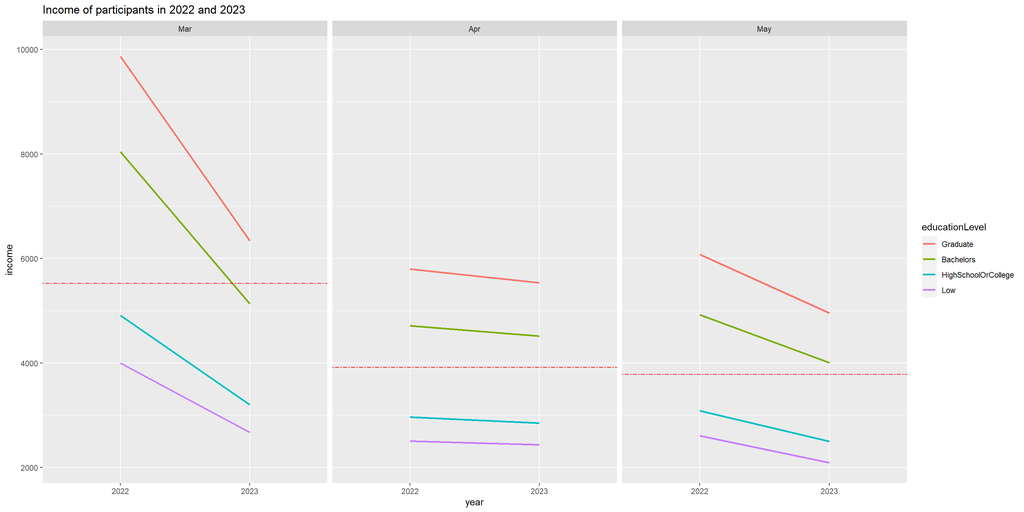

```r
Education_fin$month <- factor(month(Education_fin$date),
                    levels=1:12,
                    labels=month.abb,
                    ordered=TRUE)
Education_fin$year <- format(Education_fin$date,"%Y")

hline.data <- Education_fin %>%
  filter( month %in% c('Mar','Apr','May')) %>%
  group_by(month) %>%
  summarise(avgvalue =mean(income))


Education_fin %>%
    filter( month %in% c('Mar','Apr','May')) %>%
  ggplot()+
  geom_line(aes(x = year,
                 y = income,
                group = educationLevel,
            colour=educationLevel),
            size = 1)+
  geom_hline(aes(yintercept = avgvalue),
             data=hline.data,
             linetype=6,
             colour="red",
             size =0.5)+
  facet_grid(~month)+
  labs(axis.text.x = element_blank(),
       title = "Income of participants in 2022 and 2023")
```

From the above plot, it can be seen that there is major drop in income of all education segments in the month of March in 2023 compared to 2022. The income of April is comparable between the years and a comparatively higher drop for the month of May. It is also observed that the income drop is highest for Education Levels Graduate and Bachelors.

## Conclusion

From the above plots, we can infer the following about the financial health of the residents of Engagement, Ohio, USA.

- Financial health of the occupants have deteriorated between 2022 and 2023
- There is a major dip in Income in April, 2022 and Feb, 2023 where as the income is high in March,2022, Aug,2022 and March 2023
- Expenses of the residents have been stable during the time period of the data
- People with higher education has higher savings